# Pertemuan 4 - Pembangkitan ARMA

Nyayu Azzahra Nabila

2025-09-20

## 1 White Noise

Kita akan membangkitkan white noise, dengan ketentuan:

- nomor 1090 dipilih sebagai nomor set.seed karena ini adalah angka NIM saya
- rnorm dibangkitkan 300 baris sesuai perintah soal

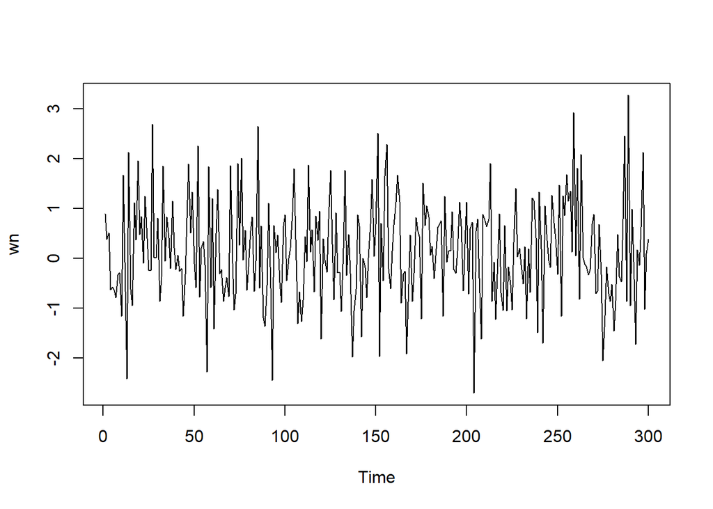

```r
set.seed(1090)
wn <- rnorm(300)
ts.plot(wn)
```

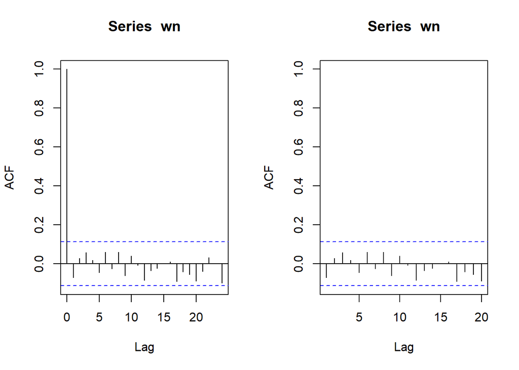

```r
par(mfrow = c(1, 2))
acf(wn)
acf(wn, xlim = c(1, 20))
```

**Interpretasi Hasil:**

- Pada plot kiri, di lag 0 nilai ACF, wajar, karena tiap data pasti berkorelasi sempurna dengan dirinya sendiri. Namun, pada lag 1 hingga lag 20, nilai ACF berada di sekitar 0, yang menunjukkan tidak ada korelasi signifikan antara nilai-nilai pada lag tersebut.
- Plot kanan memperlihatkan nilai ACF pada lag 1 hingga lag 20 dengan batas kepercayaan (confidence interval) yang ditandai oleh garis horizontal biru. Nilai ACF berada di dalam batas kepercayaan ini, yang mengindikasikan bahwa tidak ada korelasi signifikan pada lag-lag tersebut. Hal ini konsisten dengan karakteristik white noise, di mana nilai-nilai acak tidak menunjukkan pola korelasi yang signifikan.

## 2 Proses MA(2)

### 2.1 Pembangkitan Manual

Akan dibangkitkan proses MA (2) dengan $\theta_1 = 0.4$, $\theta_2 = 0.6$, $c=0$ sebanyak 300 observasi. Karena diperlukan dua nilai awal untuk $e_{t-1}$ dan $e_{t-2}$, masukkan dua nilai pertama white noise sebagai nilai awal tersebut.

```r
set.seed(1090)
ma2 <- wn[1:2]
```

Nilai-nilai selanjutnya dapat dicari melalui *loop*. Bentuk loop dapat dilihat dari rumus MA(2) yang hendak dibangkitkan:

$$y_t = e_t-0.4e_{t-1}-0.6e_{t-2}$$

```r
for(i in 3:300){
  ma2[i] <- wn[i] - 0.4*wn[i-1] - 0.6*wn[i-2]
}
```

### 2.2 Pembangkitan dengan arima.sim

```r
ma2_ <- arima.sim(model=list(order=c(0,0,2), ma=c(0.4,0.6)), n=300)
ma2_
```

```
## Time Series:
## Start = 1
## End = 300
## Frequency = 1
##   [1]  1.211104758 -0.183753468 -0.517035153 -1.241232832 -1.386332554
##   [6] -1.018623474 -0.884946624 -1.469941419  1.041428265 -0.684498579
##  [11] -1.667171675  0.772141854 -1.209477113  0.088864963  0.375182051
##  [16]  0.252260532  2.781608566  1.491778319  2.216274595  0.531485976
##  [21]  1.717565548  0.850335069  0.685075526 -0.083698764  2.458620067
##  [26]  0.959639879  1.636131702  0.831685171 -0.531179319 -0.227900543
##  [31]  1.184157323  0.466612865  1.918007196  0.722400459  0.465055978
##  [36]  1.325911167  0.554359516  0.560983181  0.102808326 -0.360983065
##  [41] -0.265270486 -1.387793931 -0.901225021 -0.008484617  2.025168926
##  [46]  1.761598181  2.676432069  0.736548143  0.169680078  1.958404673
##  [51] -0.226466822  1.248367225 -0.043357090  0.137286747 -2.123801448
```

[output cut: 49 more lines]

### 2.3 Karakteristik Proses MA(2)

#### 2.3.1 Plot Time Series

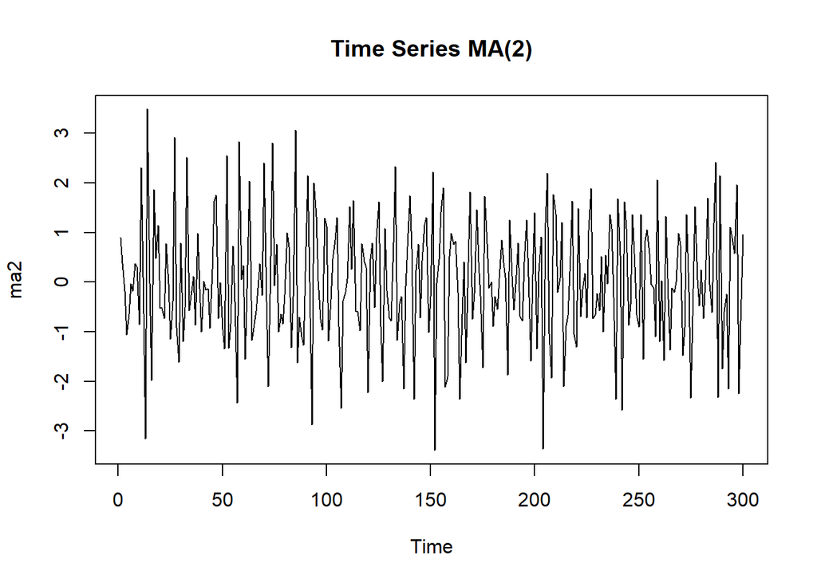

```r
ts.plot(ma2, main = "Time Series MA(2)")
```

**Interpretasi Hasil:**

- Berdasarkan plot time series, terlihat bahwa data MA(2) yang dibangkitkan stasioner dalam rataan.

#### 2.3.2 Plot ACF

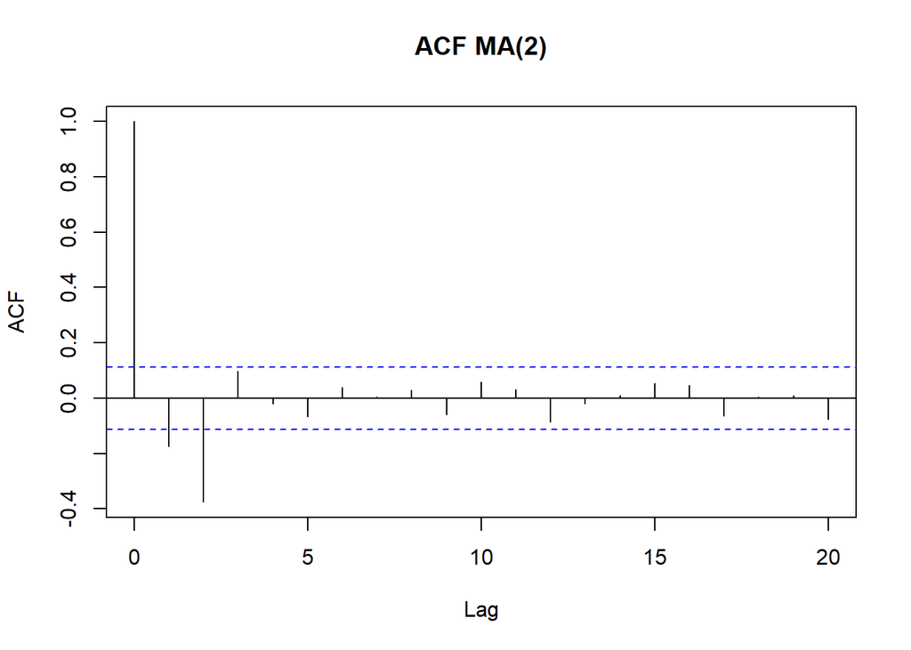

```r
acf(ma2, lag.max=20, main="ACF MA(2)")
```

**Interpretasi Hasil:**

- Berdasarkan plot ACF MA (2), menunjukkan pola cut off pada lag 2.

#### 2.3.3 Plot PACF

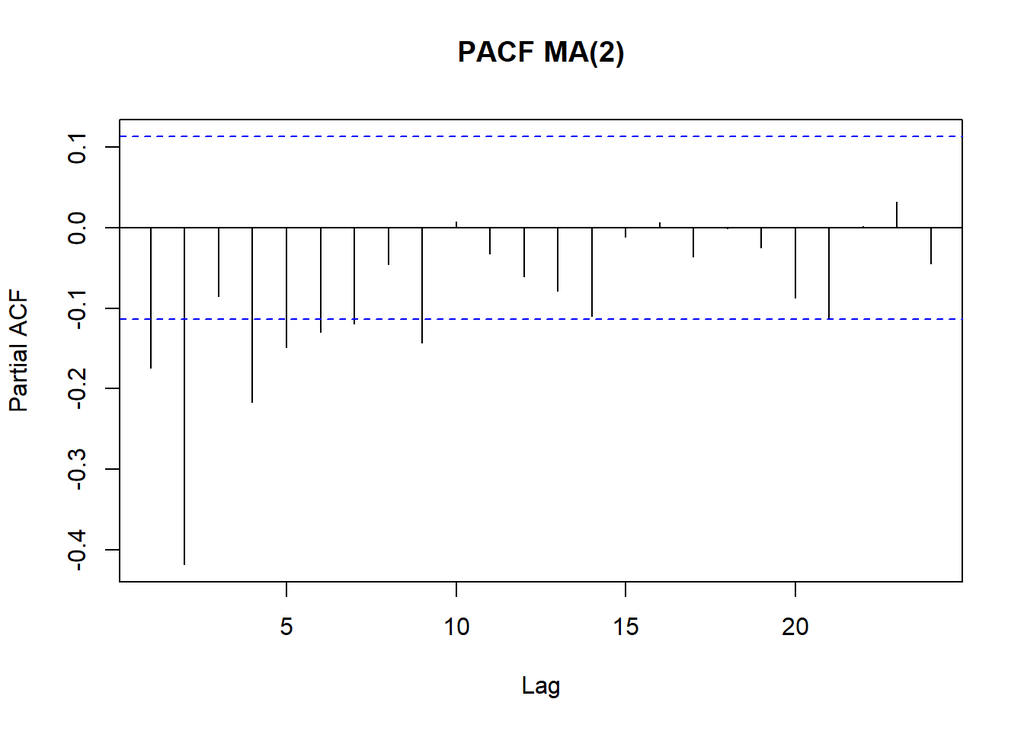

```r
pacf(ma2, main="PACF MA(2)")
```

**Interpretasi Hasil:**

- Berdasarkan plot PACF MA (2), menunjukkan pola tails off (menurun perlahan, tidak berhenti di lag tertentu).

#### 2.3.4 Plot EACF

```r
TSA::eacf(ma2)
```

```
## AR/MA
##   0 1 2 3 4 5 6 7 8 9 10 11 12 13
## 0 x x o o o o o o o o o  o  o  o
## 1 x x o o o o o o o o o  o  o  o
## 2 x x o x o o o o o o o  o  o  o
## 3 x x x o x o o o o o o  o  o  o
## 4 x o o o x o o o o o o  o  o  o
## 5 x o o o x o o o o o o  o  o  o
## 6 x o x o o x x x o o o  o  o  o
## 7 x x x o o o x x o o o  o  o  o
```

**Interpretasi Hasil:**

- Berdasarkan pola segitiga nol pada plot EACF, terlihat bahwa segitiga nol berada pada ordo AR(0) dan ordo MA(2)

#### 2.3.5 Kesimpulan: Apakah data stationer?

1. Plot time series MA (2), menunjukkan fluktuasi data naik-turun di sekitar rataan yang konstan dan variansi relatif stabil (ciri data stationer)
2. Plot ACF MA(2), terlihat cut off di lag 2, artinya hanya signifikan sampai lag 2, sisanya mendekati nol, pola ini khas untuk proses MA(2) yang stationer
3. Plot PACF MA(2), terlihat tails off (konsisten dengan sifat MA (q))
4. Plot EACF, menunjukkan segitiga nol di p=0 dan q=2, mengkonfirmasi bahwa modelnya MA(2), dengan MA(q) selalu stationer
5. Kesimpulan: berdasarkan semua plot, data telah stationer. Tidak perlu differencing.

### 2.4 Scatterplot antar Lag

#### 2.4.1 Korelasi antara $Y_t$ dengan $Y_{t-1}$

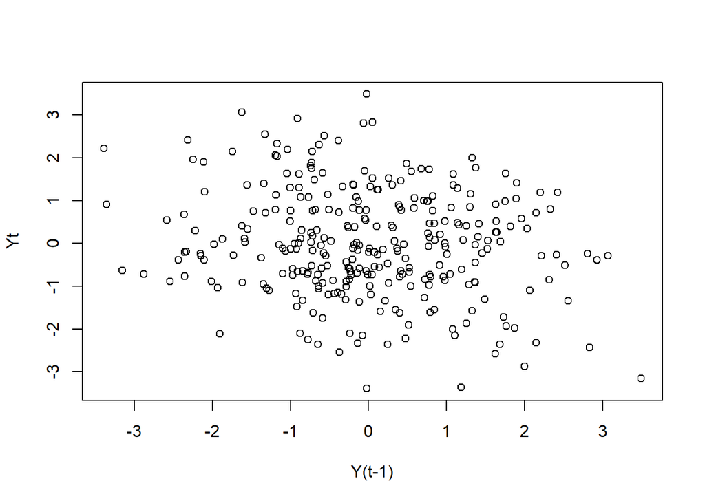

```r
plot(ma2[-1], ma2[-300], xlab="Y(t-1)", ylab="Yt")
```

```r
cor(ma2[-1], ma2[-300])
```

```
## [1] -0.1741006
```

perhitungan teoritis.

$$\rho_1 =
\frac{(-\theta_1+((\theta_1)(\theta_2))}{1-\theta_1^2+\theta_2^2}$$

```r
rho_1 <- (-0.4 + (0.4*0.6)) / (1 - 0.4^2 + 0.6^2)
rho_1
```

```
## [1] -0.1333333
```

**Interpretasi Hasil:** - Korelasi antara $Y_t$ dengan $Y_{t-1}$ dari hasil simulasi mendekati perhitungan teoritis yaitu -0.1

#### 2.4.2 Korelasi antara $Y_t$ dengan $Y_{t-2}$

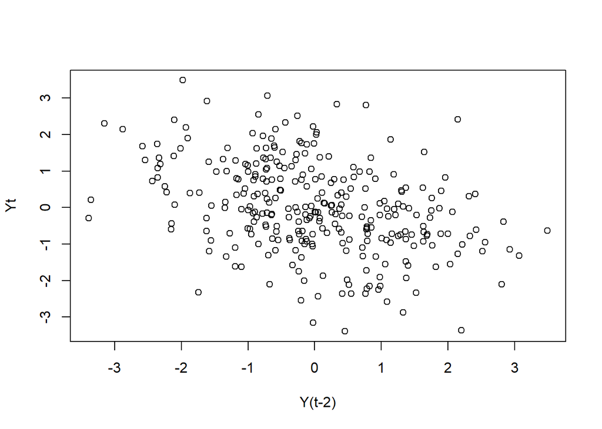

```r
plot(ma2[-c(1,2)], ma2[-c(299,300)], xlab="Y(t-2)", ylab="Yt")
```

```r
cor(ma2[-c(1,2)], ma2[-c(299,300)])
```

```
## [1] -0.3765223
```

perhitungan teoritis.

$$\rho_1 = \frac{(-\theta_2)}{1-\theta_1^2+\theta_2^2}$$

```r
rho_2 <- -0.6 / (1 + 0.4^2 + 0.6^2)
rho_2
```

```
## [1] -0.3947368
```

**Interpretasi Hasil:** - Korelasi antara $Y_t$ dengan $Y_{t-2}$ dari hasil simulasi mendekati perhitungan teoritis yaitu -0.4

#### 2.4.3 Korelasi antara $Y_t$ dengan $Y_{t-3}$

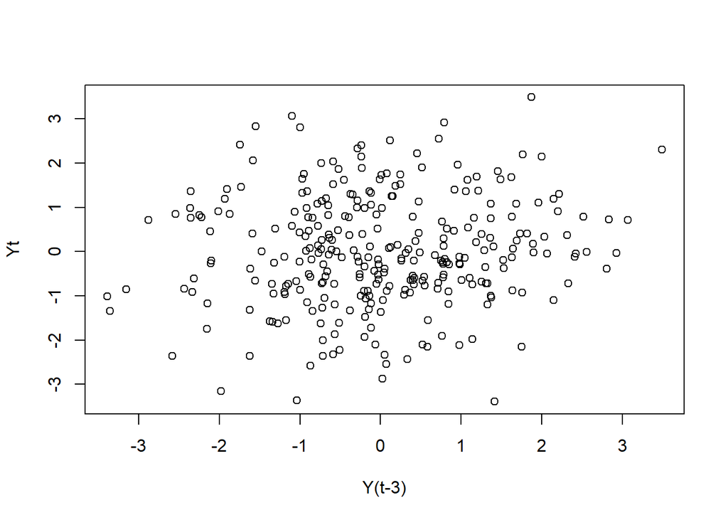

```r
plot(ma2[-c(1,2,3)], ma2[-c(298,299,300)], xlab="Y(t-3)", ylab="Yt")
```

```r
cor(ma2[-c(1,2,3)], ma2[-c(298,299,300)])
```

```
## [1] 0.09808009
```

untuk perhitungan teoritis, maka $\rho_k = 0$ untuk k > 2, hal ini sesuai dengan hasil simulasi yang mendekati 0.

## 3 Proses AR(2)

### 3.1 Pembangkitan Manual

```r
set.seed(1090)
wn <- rnorm(300)
ar2 <- rep(0, 300)
ar2[1] <- wn[1]
ar2[2] <- 0.5*ar2[1] + wn[2]
```

Nilai-nilai selanjutnya dapat dicari melalui loop. Bentuk loop dapat dilihat dari rumus AR(2) yang hendak dibangkitkan:

$$Y_t = e_t+0.5Y_{t-1} + 0.2Y_{t-2}$$

```r
for(i in 3:300){
  ar2[i] <- 0.5*ar2[i-1] + 0.2*ar2[i-2] + wn[i]
}
```

### 3.2 Pembangkitan dengan arima.sim

```r
set.seed(1090)
ar2_ <- arima.sim(list(order=c(2,0,0), ar=c(0.5, 0.2)), n=300)
```

### 3.3 Karakteristik Proses AR(2)

#### 3.3.1 Plot Time Series

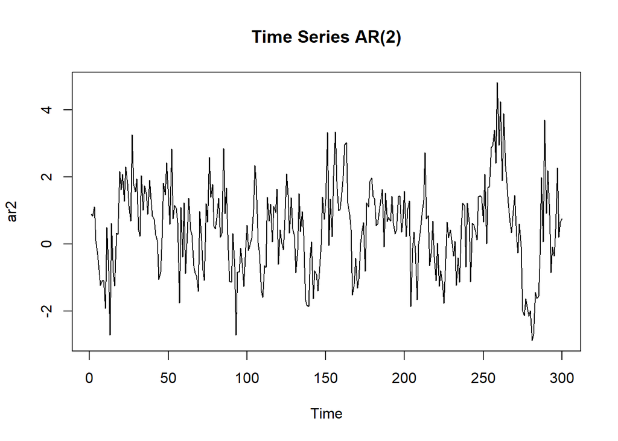

```r
ts.plot(ar2, main="Time Series AR(2)")
```

**Interpretasi Hasil:**

- Rata-rata fluktuasi terlihat konstan di sekitar rataan, sehingga data AR(2) stasioner dalam rataan. Variansi tampak relatif stabil, tidak terlihat pola musiman berkala. Sehingga, data stationer.

#### 3.3.2 Plot ACF

```r
par(mfrow=c(1,3))
```

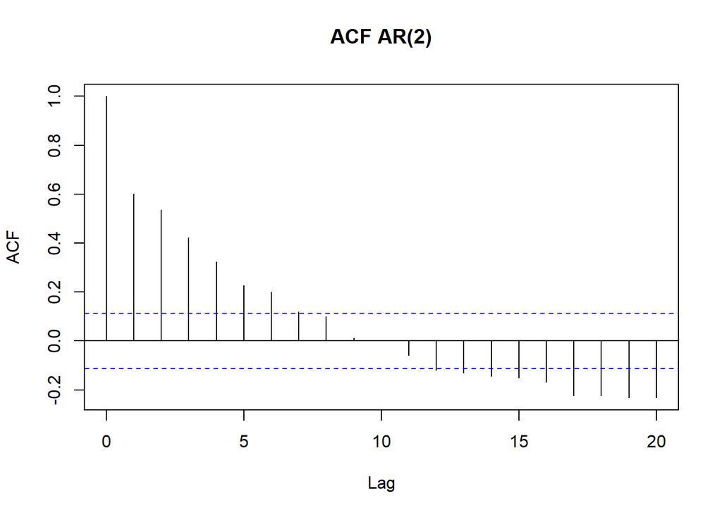

```r
acf(ar2, lag.max=20, main="ACF AR(2)")
```

**Interpretasi Hasil:**

- pada plot ACF AR(2), terlihat pola tails off (menurun perlahan)

#### 3.3.3 Plot PACF

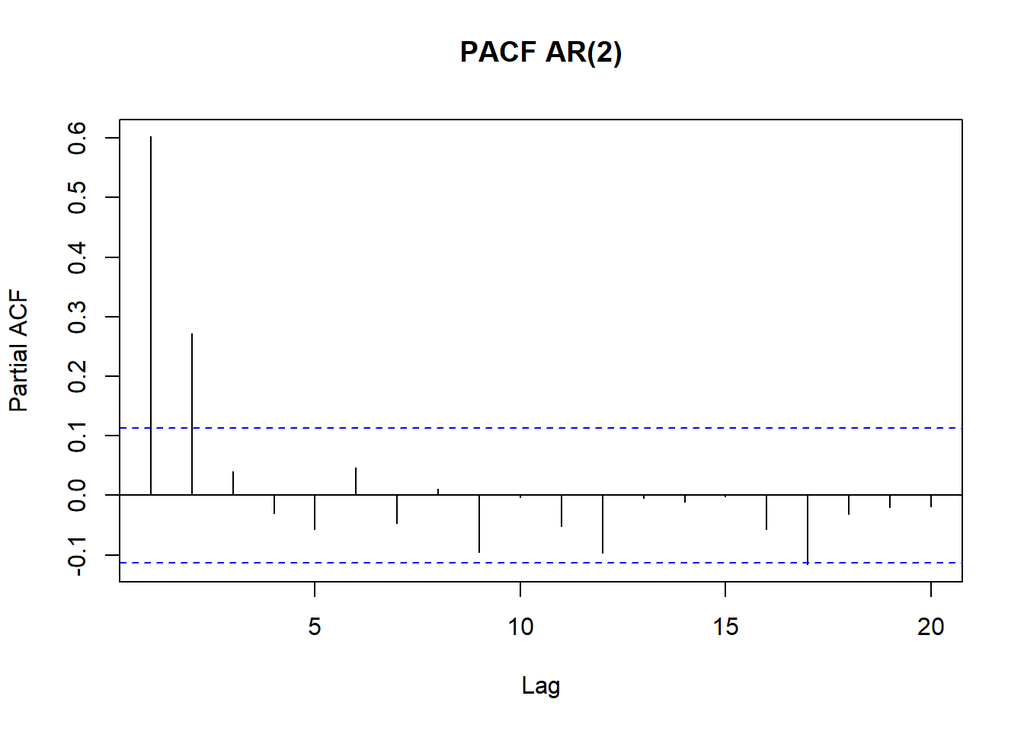

```r
pacf(ar2, lag.max=20, main="PACF AR(2)")
```

**Interpretasi Hasil:**

- pada plot ACF AR(2), PACF cut-off di lag 2, ini menegaskan bahwa data yang kita bangkitkan memang sesuai dengan spesifikasi AR(2) (φ1 = 0.5, φ2 = 0.2).

#### 3.3.4 Plot EACF

```r
TSA::eacf(ar2)
```

```
## AR/MA
##   0 1 2 3 4 5 6 7 8 9 10 11 12 13
## 0 x x x x x x x o o o o  x  x  x
## 1 x o o o o o o o o o o  o  o  o
## 2 x x o o o o o o o o o  o  o  o
## 3 x o o o o o o o o o o  o  o  o
## 4 x x x o o o o o o o o  o  o  o
## 5 x o x o o o o o o o o  o  o  o
## 6 x x o x o o o o o o o  o  o  o
## 7 x x o x x o o o o o o  o  o  o
```

### 3.4 Scatterplot antar Lag

#### 3.4.1 Korelasi antara $Y_t$ dengan $Y_{t-1}$

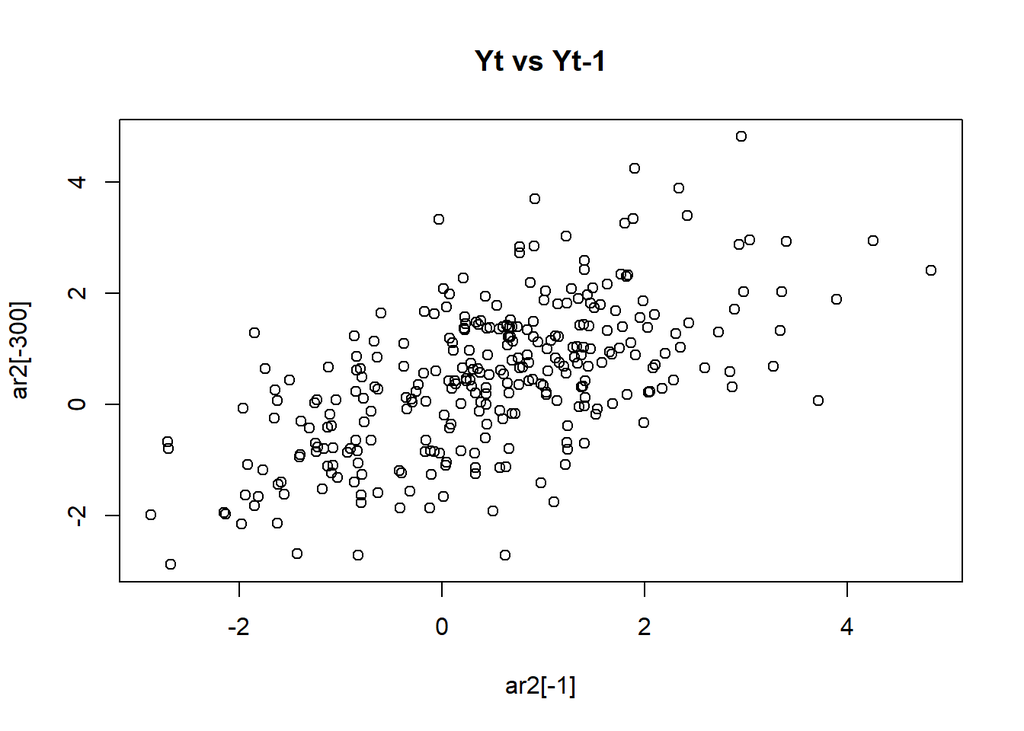

```r
plot(ar2[-1], ar2[-300], main="Yt vs Yt-1")
```

```r
cor(ar2[-1], ar2[-300])
```

```
## [1] 0.6024599
```

perhitungan teoritis.

$$\rho_1 = \frac{\phi_1}{1-\phi_2}$$

```r
rho_1 <- 0.5 / (1 - 0.2)
rho_1
```

```
## [1] 0.625
```

**Interpretasi Hasil:**

- Korelasi antara $Y_t$ dengan $Y_{t-1}$ dari hasil simulasi mendekati perhitungan teoritis yaitu 0.6

#### 3.4.2 Korelasi antara $Y_t$ dengan $Y_{t-2}$

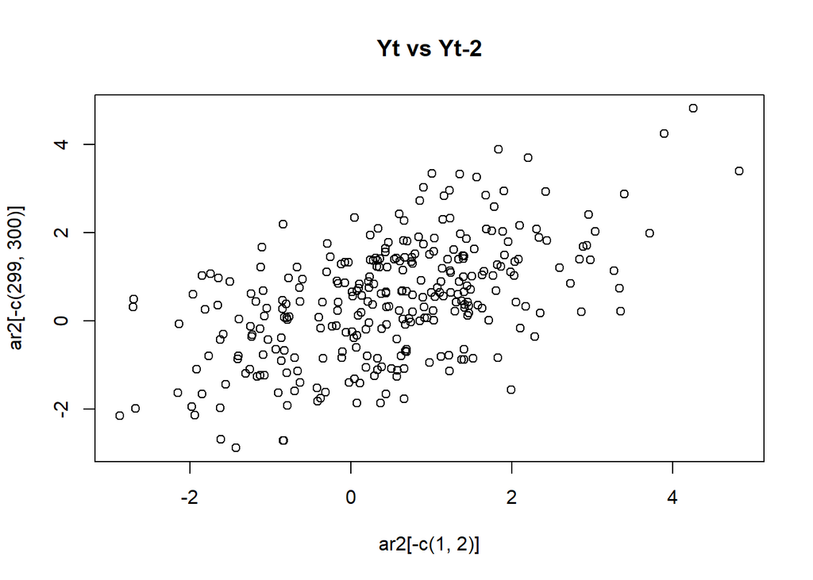

```r
plot(ar2[-c(1,2)], ar2[-c(299,300)], main="Yt vs Yt-2")
```

```r
cor(ar2[-c(1,2)], ar2[-c(299,300)])
```

```
## [1] 0.5358236
```

perhitungan teoritis.

$$\rho_1 = \frac{\phi_2(1-\phi_2)+\phi_1^2}{1-\phi_2}$$

```r
rho_2 <- (0.2*(1-0.2) + 0.5^2) / (1 - 0.2)
rho_2
```

```
## [1] 0.5125
```

**Interpretasi Hasil:**

- Korelasi antara $Y_t$ dengan $Y_{t-2}$ dari hasil simulasi mendekati perhitungan teoritis yaitu 0.5

#### 3.4.3 Korelasi antara $Y_t$ dengan $Y_{t-3}$

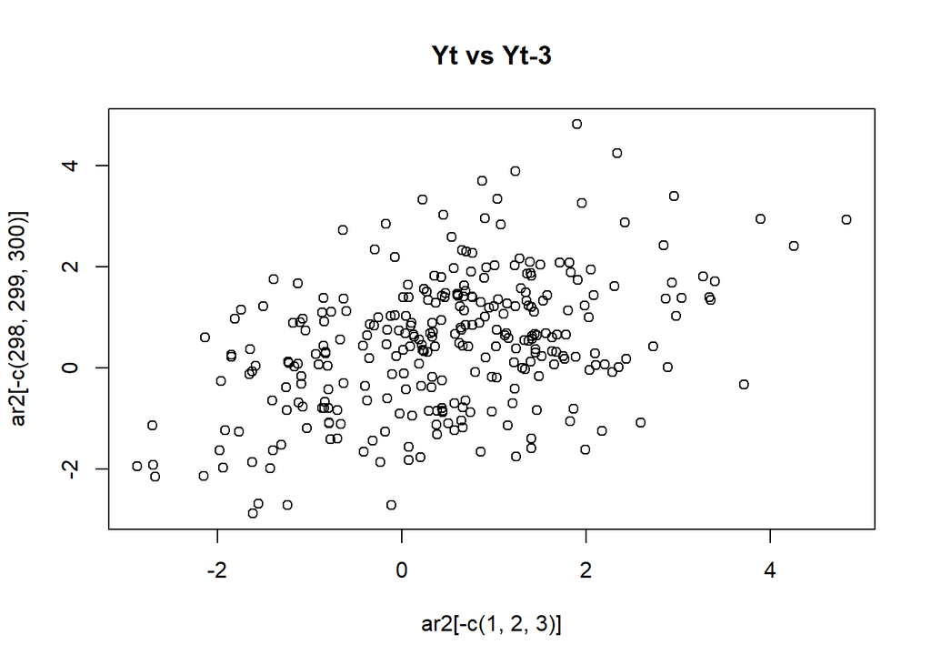

```r
plot(ar2[-c(1,2,3)], ar2[-c(298,299,300)], main="Yt vs Yt-3")
```

```r
cor(ar2[-c(1,2,3)], ar2[-c(298,299,300)])
```

```
## [1] 0.4223741
```

perhitungan teoritis.

$$\rho_1 = {\phi_1(\rho_{k-1})+\phi_2(\rho_{k-2})}$$

```r
rho_3 <- 0.5*rho_2 + 0.2*rho_1
rho_3
```

```
## [1] 0.38125
```

**Interpretasi Hasil:**

- Korelasi antara $Y_t$ dengan $Y_{t-3}$ dari hasil simulasi mendekati perhitungan teoritis yaitu 0.4

## 4 Proses ARMA(2,2)

### 4.1 Pembangkitan Manual

Akan dicoba membangkitkan proses ARMA(2,2) dengan $\phi_1 = 0.5$, $\phi_2 = 0.2$, $\theta_1 = 0.4$, $\theta_2 = 0.6$ sebanyak 300 observasi dan $c=0$.

```r
set.seed(1090)

# fungsi dari asprak
arma.sim <- function(n, macoef, arcoef){
  manum <- length(macoef)
  arnum <- length(arcoef)
  stopifnot(manum < n & arnum < n)

  wn <- rnorm(n, sd = 0.5)
  init <- max(manum, arnum)

  arma <- wn[1:init]
  for(i in (init+1):n){
    mastart <- i - manum
    maend <- i-1
    arstart <- i - arnum
    arend <- i-1
    arma[i] <- sum(arcoef * arma[arstart:arend]) +
               sum(macoef * wn[mastart:maend]) +
               wn[i]
  }
  return(arma)
}

arma22 <- arma.sim(300, macoef = c(0.4, 0.6), arcoef = c(0.5, 0.2))
arma22
```

```
##   [1]  0.448872442  0.193985053  0.817808133  0.181607387  0.072636644
##   [6] -0.510743014 -0.764790484 -0.932559171 -0.965165993 -1.390450869
##  [11] -0.327720204 -0.819076904 -1.394774049 -0.477649669 -0.943525591
##  [16] -0.657774937 -0.448499518 -0.085909814  1.074125149  1.076864675
##  [21]  1.713096073  1.182771626  1.857501480  1.522828811  1.491851343
##  [26]  0.954145406  2.165105065  1.682803359  1.970700988  1.649891050
##  [31]  1.129778597  0.769544751  1.360143545  1.112050383  1.671393874
##  [36]  1.339514539  1.295417967  1.529539739  1.366210811  1.224536833
##  [41]  0.936417544  0.646822738  0.433253634 -0.278247242 -0.385111872
##  [46] -0.136893298  0.905811944  1.101518350  1.873969948  1.375490805
##  [51]  1.152742791  1.849483503  1.117620492  1.468935666  0.929056273
##  [56]  1.002603332 -0.443142349  0.627744602 -0.288464703  1.055878352
##  [61] -0.394018071  0.520352340  0.471285295  0.717156681  0.454608680
##  [66] -0.109290377 -0.392032324 -0.674764458 -0.948936076  0.099152112
##  [71] -0.097038515 -0.138490984 -0.757889358  0.314275253  0.249376573
```

[output cut: 45 more lines]

### 4.2 Pembangkitan dengan arima.sim

```r
set.seed(1090)

arma22_ <- arima.sim(
  list(order = c(2,0,2),
       ar = c(0.5, 0.2),
       ma = c(0.4, 0.6)),
  n = 300
)

arma22_
```

```
## Time Series:
## Start = 1
## End = 300
## Frequency = 1
##   [1]  3.52236166  4.24311330  3.65771415  2.14630042  1.57679250  2.40181366
##   [7]  1.98287819  3.38980902  2.81388061  2.54995809  3.16366633  2.64618430
##  [13]  2.51680860  1.89044948  1.08760340  0.65662111 -0.84196270 -1.19088215
##  [19] -0.77231823  1.40083338  2.30755123  4.11037436  3.25324557  2.61837773
##  [25]  3.91824265  2.25633005  3.16018078  1.98799931  1.76332256 -0.84454031
##  [31]  0.79213951 -0.98302197  1.75185877 -0.60066118  0.71735936  0.98241847
##  [37]  1.18371734  1.27968900 -0.25971951 -0.94002403 -1.65972871 -2.29504325
##  [43] -0.14983967 -0.34614045 -0.14721558 -1.32059700  0.31705453  0.50243964
##  [49]  3.58500817  2.83538039  3.89625304  2.08907725  1.74355637  1.39983225
##  [55]  2.00821453  1.29781875  1.23573012  3.11912689  2.24473566  3.75180498
##  [61]  1.03841110 -0.17414265 -1.67829739 -0.79106921 -1.21007723 -2.78160378
```

[output cut: 39 more lines]

### 4.3 Karakteristik Proses ARMA(2,2)

#### 4.3.1 Plot Time Series

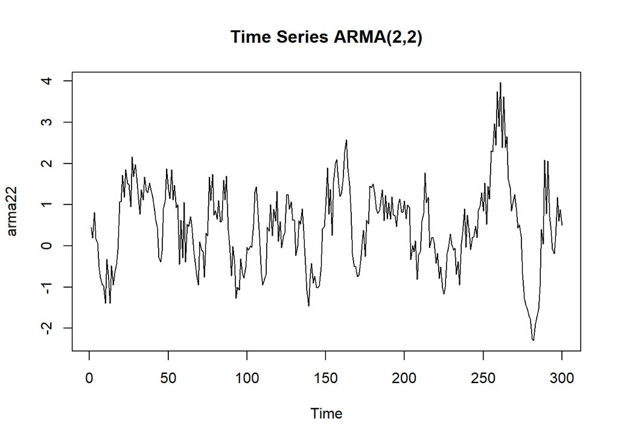

```r
ts.plot(arma22, main="Time Series ARMA(2,2)")
```

**Interpretasi Hasil:**

- Rata-rata fluktuasi terlihat konstan di sekitar rataan, sehingga data ARMA(2,2) stasioner dalam rataan. Variansi tampak relatif stabil, tidak terlihat pola musiman berkala. Sehingga, data stationer.

#### 4.3.2 Plot ACF

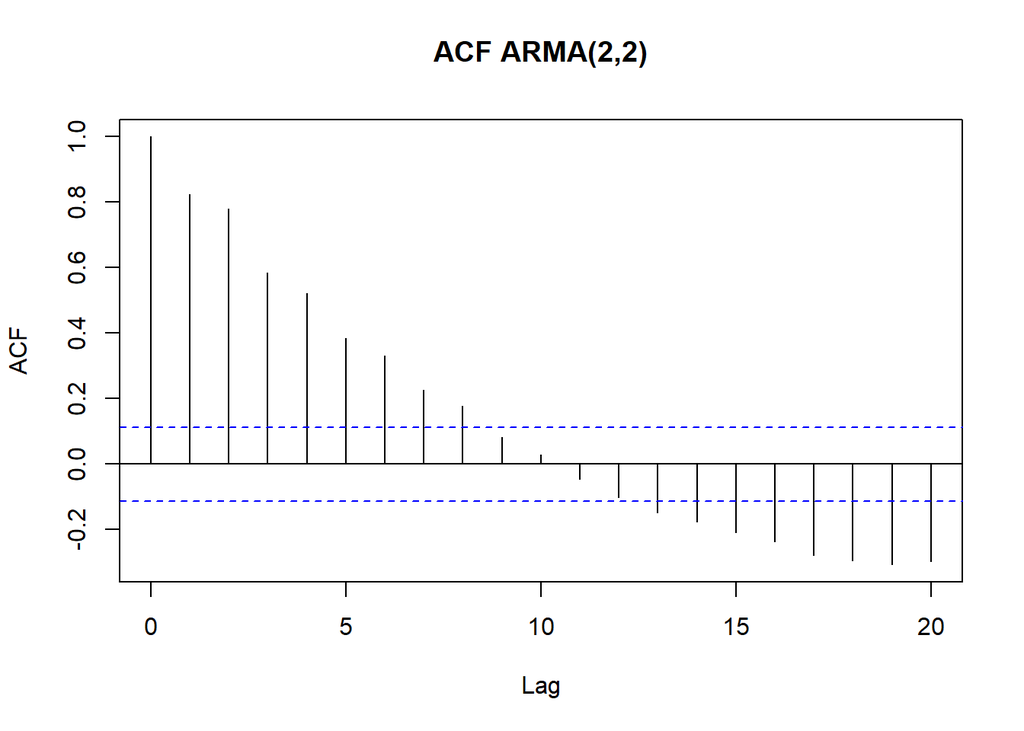

```r
acf(arma22, lag.max = 20, main = "ACF ARMA(2,2)")
```

**Interpretasi Hasil:**

- Berdasarkan plot ACF tersebut, terlihat bahwa model ARMA(2,2) hasil simulasi memiliki plot ACF yang tails off, sesuai dengan teori yang ada

#### 4.3.3 Plot PACF

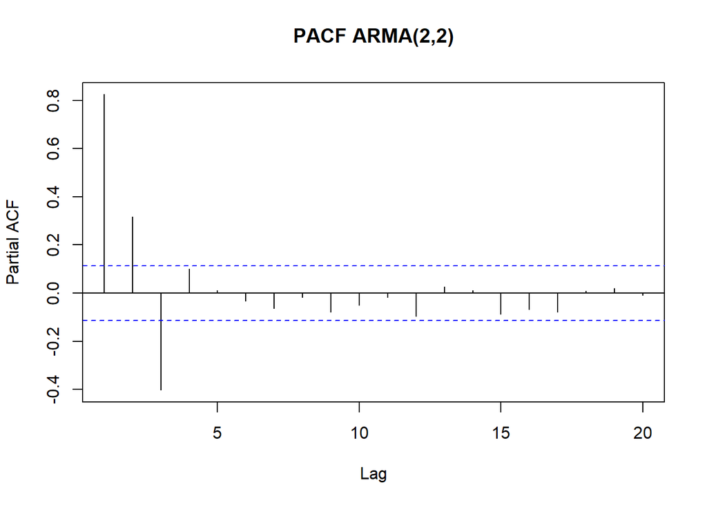

```r
pacf(arma22, lag.max = 20, main = "PACF ARMA(2,2)")
```

#### 4.3.4 Plot EACF

```r
TSA::eacf(arma22)
```

```
## AR/MA
##   0 1 2 3 4 5 6 7 8 9 10 11 12 13
## 0 x x x x x x x x o o o  o  x  x
## 1 x x x x x x o x o o o  o  o  o
## 2 x x o o o x o x o o o  o  o  o
## 3 x o o o o o o o o o o  o  o  o
## 4 o x o x o o o o o o o  o  o  o
## 5 x x o o o o o o o o o  o  o  o
## 6 x x x o o o o o o o o  o  o  o
## 7 x x x o o o o o o o o  o  o  o
```

**Interpretasi Hasil:**

- Berdasarkan pola segitiga nol pada plot EACF, terlihat bahwa segitiga nol berada pada ordo AR(2) dan ordo MA(2)

### 4.4 Scatterplot antar Lag

#### 4.4.1 Korelasi antara $Y_t$ dengan $Y_{t-1}$

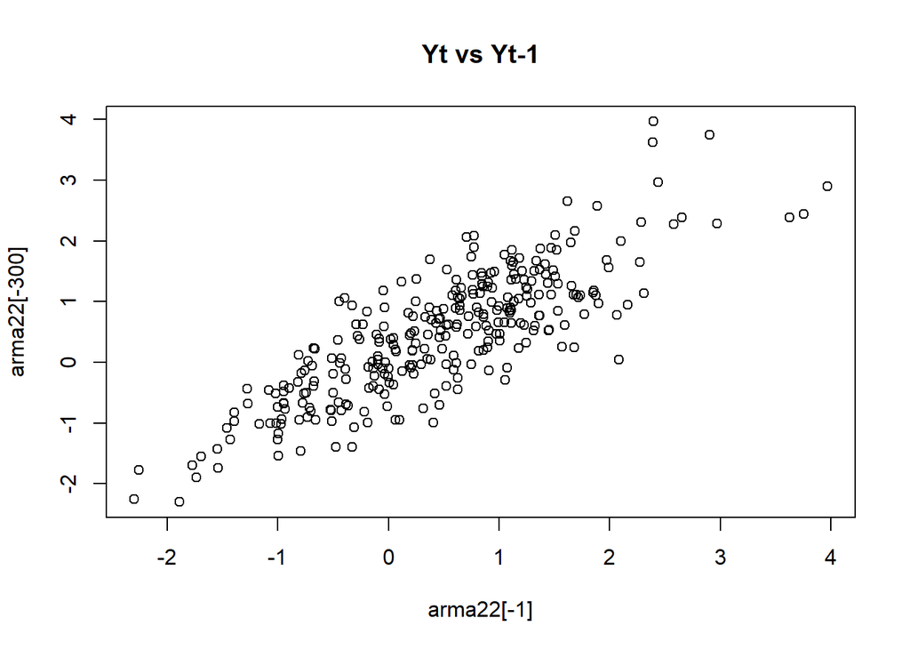

```r
plot(arma22[-1], arma22[-300], main="Yt vs Yt-1")
```

```r
cor(arma22[-1], arma22[-300])
```

```
## [1] 0.8245595
```

#### 4.4.2 Korelasi antara $Y_t$ dengan $Y_{t-2}$

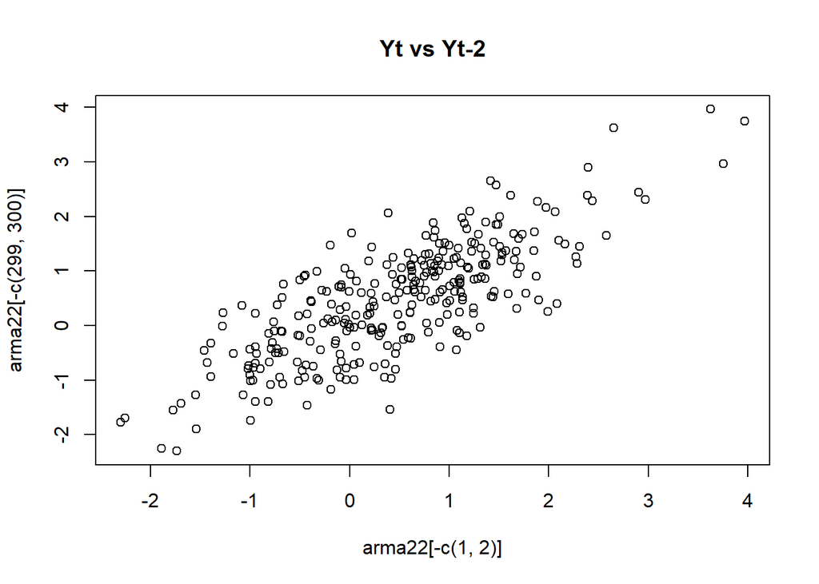

```r
plot(arma22[-c(1,2)], arma22[-c(299,300)], main="Yt vs Yt-2")
```

```r
cor(arma22[-c(1,2)], arma22[-c(299,300)])
```

```
## [1] 0.7812933
```

#### 4.4.3 Korelasi antara $Y_t$ dengan $Y_{t-3}$

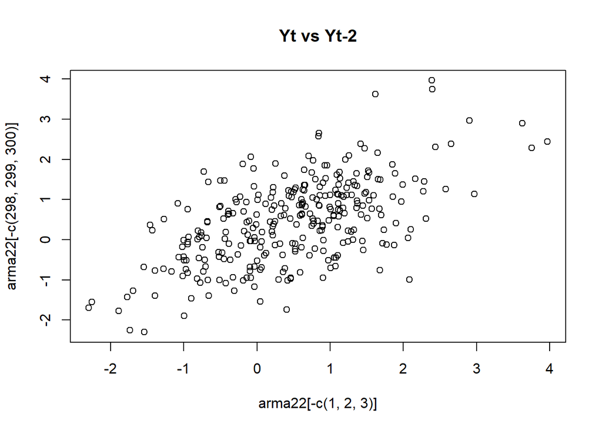

```r
plot(arma22[-c(1,2,3)], arma22[-c(298,299,300)], main="Yt vs Yt-2")
```

```r
cor(arma22[-c(1,2,3)], arma22[-c(298,299,300)])
```

```
## [1] 0.5854582
```

#### 4.4.4 Perhitungan teoritis

$$\rho_k = \frac {\gamma_k}{\gamma_0}$$
dengan
$$\gamma_k = \sigma_e^2 \sum_{j=0}^{\infty} \psi_j \psi_{j+k}$$
dimana,
$$\[
\begin{aligned}
\psi_0 &= 1, \\[6pt]
\psi_1 &= \theta_1 + \phi_1, \\[6pt]
\psi_2 &= \theta_2 + \phi_1 \psi_1 + \phi_2, \\[6pt]
\psi_j &= \phi_1 \psi_{j-1} + \phi_2 \psi_{j-2}, \quad \text{untuk }
j \geq 3.
\end{aligned}
\]$$

sehingga
$$\rho_1 = \frac{\sum_{j=0}^{\infty} \psi_j
\psi_{j+1}}{\sum_{j=0}^{\infty} \psi_j^2}$$
$$\rho_2 = \frac{\sum_{j=0}^{\infty} \psi_j
\psi_{j+2}}{\sum_{j=0}^{\infty} \psi_j^2}$$
$$\rho_3 = \frac{\sum_{j=0}^{\infty} \psi_j
\psi_{j+3}}{\sum_{j=0}^{\infty} \psi_j^2}$$

```r
# parameter
phi1 <- 0.5; phi2 <- 0.2
theta1 <- 0.4; theta2 <- 0.6
sigma2 <- 1
M <- 200   # banyak psi terms untuk aproksimasi

# compute psi_0..psi_M
psi <- numeric(M+1)
psi[1] <- 1        # psi_0 stored at index 1
psi[2] <- theta1 + phi1    # psi_1
# psi_2:
psi[3] <- theta2 + phi1*psi[2] + phi2

if(M >= 3){
  for(j in 4:(M+1)){       # j corresponds to psi_{j-1}
    idx <- j-1
    psi[j] <- phi1*psi[idx-1] + phi2*psi[idx-2]  # psi_j = phi1*psi_{j-1} + phi2*psi_{j-2}
  }
}

# compute gamma_k for k = 0..K
K <- 5
gamma <- numeric(K+1)
for(k in 0:K){
  s <- 0
  for(j in 0:(M-k)){
    s <- s + psi[j+1]*psi[j+k+1]   # +1 karena index R
  }
  gamma[k+1] <- sigma2 * s
}
rho <- gamma / gamma[1]   # rho_k = gamma_k / gamma_0

# print rho1, rho2, rho3
rho1 <- rho[2]; rho2 <- rho[3]; rho3 <- rho[4]
data.frame(k = 1:3, rho = c(rho1, rho2, rho3))
```

```
##   k       rho
## 1 1 0.8628288
## 2 2 0.8016532
## 3 3 0.6314144
```

**Interpretasi Hasil:**

- Korelasi antara $Y_t$ dengan $Y_{t-1}$ dari hasil simulasi mendekati perhitungan teoritis yaitu 0.8
- Korelasi antara $Y_t$ dengan $Y_{t-2}$ dari hasil simulasi mendekati perhitungan teoritis yaitu 0.8
- Korelasi antara $Y_t$ dengan $Y_{t-3}$ dari hasil simulasi mendekati perhitungan teoritis yaitu 0.6